# Revision_logistic_regression

Hanna Mahler

26 3 2020

# 1. Logistic Regression: Revision

[Most of the information in this script is based on Levshina (2015:253-276)]

Logistic regression attempts to predict a categorical outcome from categorical and/or numeric predictors. If the outcome variable has only two possible values, we speak of “binomial” logistic regression, otherwise of “multinomial” logistic regression. There are two main methods to select predictor variables: - forced entry method: enter all predictors at once - stepwise methods: - forward: add individual predictors one after another - backward: remove predictors one after another The model output indicates how the probability of the outcome is influenced by the predictors (note the additional explanation below on log odds and ratios in 5.!).

# 2. The data set: Aspectual choice for verbs of bodily sensation

This data set was collected to provide insights in the progressive alternation for verbs of bodily sensation (‘hurt’, ‘ache’, ‘itch’). It is a cleaned sample retrieved from the BNC2014 (searching for the three verbs in both aspects). Quirk et al. (2010:203) claim that, for this sub-category, “the progressive and the nonprogressive are more or less interchangeable when referring to temporary states”. We will try to find out whether the progressive and non-progressive are really interchangeable or whether the aspectual choice might be influenced by one or more factors.

In our logistic regression model, the binary outcome variable will be the factor “progressive” or “non-progressive” for each utterance. Based on previous research, the following explanatory variables might be relevant: - Experiencer: since the progressive has a connotation of increased emotionality and subjectivity, we can expect it to occur more often if the person experiencing the sensation is the speaker (“1st”) and not the interlocutor (“2nd”) or another person (“3rd”) - Subject group: semantic group of the grammatical subject - Presence of intensifier: due to the connotation of increased emotionality, intensifiers might occur more frequently with the progressive - Verb tense: can be present, past, or future - Duration: can be “temporary” or “long-term”, the progressive should theoretically be favoured with temporary events - Pain at utterance time: due to the connotation of increased emotionality, we can expect the progressive to be favoured if the sensation described happens at the moment of utterance (instead of as part of a narration) - Word count of the utterace: does not really have any theoretical relevance, but we needed a numeric predictor for illustration ;-)

# 1. Load libraries

# 2. Load data

```r
ING_data <- read_excel("C:/Users/mahle/Documents/Universität/01_Master/Unterlagen/Statistics/data/Revision_logistic_regression_data.xlsx")
head(ING_data)
```

| ID | Text | Verb | Progressive | Experiencer | Subject_group | Intensifier_presence | Verb_tense | Duration | Pain_at_UT | Word_count |
| --- | --- | --- | --- | --- | --- | --- | --- | --- | --- | --- |
| 1 | do it [S0024:] yeah [S0144:] he ca n't say ph my leg 's hurting and I wo n't I 'm not I ca n't | HURT | progressive | 3rd | body part | NO | present | long-term | NO | 4 |
| 2 | sat there and sort of laughed to myself cos I was n't hurting anywhere [S0238:] I mean you were flipping lucky that you were | HURT | progressive | 1st | speaker | NO | past | temporary | NO | 5 |
| 3 | s that (.) yes my leg pit if my leg pit is hurting at night (.) what does that mean ? [S0652:] mm hm [S0653:] gremlins | HURT | progressive | 1st | body part | NO | present | long-term | NO | 8 |
| 4 | re like you 're aching in your bo- like you 're just hurting you ca n't really move that well [S0632:] this is why | HURT | progressive | 3rd | human being | YES | present | temporary | NO | 4 |
| 5 | on to it (.) that is it (.) that 's why it 's hurting so much [S0086:] stop it you 're making it worse (.) stop | HURT | progressive | 3rd | body part | YES | present | temporary | YES | 8 |
| 6 | how serious a conversation is he can see that you 're hurting which then upsets him (.) fine (.) so you know it 's | HURT | progressive | 2nd | human being | NO | present | temporary | NO | 7 |

# 3. Prepare data

```r
ING_data$Verb = factor(ING_data$Verb, levels = c("HURT", "ACHE", "ITCH"))
ING_data$Progressive = factor(ING_data$Progressive, levels = c("non-progressive", "progressive"))
ING_data$Experiencer = factor(ING_data$Experiencer, levels = c("1st", "2nd", "3rd"))
ING_data$Subject_group = factor(ING_data$Subject_group, levels = c("speaker", "body part", "human being", "action", "object"))
ING_data$Intensifier_presence = factor(ING_data$Intensifier_presence, levels = c("NO", "YES"))
ING_data$Verb_tense = factor(ING_data$Verb_tense, levels = c("present", "past", "future"))
ING_data$Duration = factor(ING_data$Duration, levels = c("temporary", "long-term"))
ING_data$Pain_at_UT = factor(ING_data$Pain_at_UT, levels = c("YES", "NO"))
summary(ING_data)
```

```
##        ID             Text             Verb             Progressive Experiencer
##  Min.   :  1.00   Length:136         HURT:88   non-progressive:69   1st:92
##  1st Qu.: 35.75   Class :character   ACHE:33   progressive    :67   2nd:15
##  Median : 69.50   Mode  :character   ITCH:15                        3rd:29
##  Mean   : 69.26
##  3rd Qu.:103.25
##  Max.   :137.00
##      Subject_group Intensifier_presence   Verb_tense      Duration  Pain_at_UT
##  speaker    : 6    NO :104              present:98   temporary:89   YES:64
##  body part  :93    YES: 32              past   :35   long-term:47   NO :72
##  human being: 9                         future : 3
##  action     :22
##  object     : 6
##
##    Word_count
##  Min.   : 2.000
##  1st Qu.: 3.000
##  Median : 4.500
##  Mean   : 4.882
##  3rd Qu.: 6.000
##  Max.   :10.000
```

Due to an unqueal distribution of values, there are some factors that need to be treated with caution. Which? -> Subject_group (few data points for speaker, human being, and object) -> Verb_tense (few data points for future)

# 4. Perfom logistic regression model

There are two formulas for performing a logistic regression model: lrm(outcome ~ predictor1 + predictor2, data = dataset, na.action = na.exclude) glm(outcome ~ predictor1 + predictor2, data = dataset, na.action = na.exlcude, family = “binomial”)

We will use both, as they have different properties attached to them which are needed for the testing of assumptions later on. Here is a quick overview which function can be used for what: - lrm(): forced-entry only, provides model statistics, test assumption of mulitcollinearity, check for overfitting - glm(): for stepwise selection and forced-entry, for ANOVA comparisons, does not provide model statistics, test assumption of linearity, check for outliers and influential cases

To see the output of the lrm() model, just type the model name, for the glm() model, use summary(model)

## 4.1 Forced entry

Use both functions to create two regression models, using the forced-entry method (so including all predictors).

```r
model.1 = lrm(Progressive ~ Experiencer + Subject_group + Intensifier_presence + Word_count + Verb_tense +
                Duration + Pain_at_UT , data = ING_data)
model.1
```

```
## Logistic Regression Model
##
##  lrm(formula = Progressive ~ Experiencer + Subject_group + Intensifier_presence +
##      Word_count + Verb_tense + Duration + Pain_at_UT, data = ING_data)
##
##                          Model Likelihood    Discrimination    Rank Discrim.
##                                Ratio Test           Indexes          Indexes
##  Obs            136    LR chi2      56.79    R2       0.455    C       0.840
##   non-progressive69    d.f.            12    g        2.160    Dxy     0.680
##   progressive    67    Pr(> chi2) <0.0001    gr       8.672    gamma   0.684
##  max |deriv| 0.0001                          gp       0.345    tau-a   0.342
##                                              Brier    0.162
##
##                            Coef    S.E.   Wald Z Pr(>|Z|)
##  Intercept                 -0.6239 1.3307 -0.47  0.6392
##  Experiencer=2nd            0.1624 0.7616  0.21  0.8312
##  Experiencer=3rd            0.4549 0.6488  0.70  0.4832
##  Subject_group=body part   -0.7832 1.1639 -0.67  0.5010
##  Subject_group=human being  1.2620 1.6566  0.76  0.4462
##  Subject_group=action      -4.9019 1.6201 -3.03  0.0025
##  Subject_group=object      -1.6833 1.7581 -0.96  0.3383
##  Intensifier_presence=YES  -0.0932 0.5785 -0.16  0.8721
##  Word_count                 0.3731 0.1280  2.91  0.0036
##  Verb_tense=past            1.7219 0.6446  2.67  0.0076
##  Verb_tense=future          2.2043 1.7691  1.25  0.2128
##  Duration=long-term        -0.7595 0.4966 -1.53  0.1262
##  Pain_at_UT=NO             -0.7867 0.5447 -1.44  0.1486
##
```

```r
model.2 = glm(Progressive ~ Experiencer + Subject_group + Intensifier_presence + Word_count +
                Duration + Verb_tense + Pain_at_UT , data = ING_data, family = "binomial")
summary(model.2)
```

```
##
## Call:
## glm(formula = Progressive ~ Experiencer + Subject_group + Intensifier_presence +
##     Word_count + Duration + Verb_tense + Pain_at_UT, family = "binomial",
##     data = ING_data)
##
## Deviance Residuals:
##      Min        1Q    Median        3Q       Max
## -1.95694  -0.76652  -0.06592   0.75730   2.64648
##
## Coefficients:
##                          Estimate Std. Error z value Pr(>|z|)
## (Intercept)              -0.62388    1.33073  -0.469  0.63919
## Experiencer2nd            0.16239    0.76164   0.213  0.83116
## Experiencer3rd            0.45491    0.64880   0.701  0.48321
## Subject_groupbody part   -0.78317    1.16393  -0.673  0.50103
## Subject_grouphuman being  1.26195    1.65658   0.762  0.44619
## Subject_groupaction      -4.90194    1.62015  -3.026  0.00248 **
## Subject_groupobject      -1.68330    1.75813  -0.957  0.33835
## Intensifier_presenceYES  -0.09316    0.57854  -0.161  0.87207
## Word_count                0.37310    0.12801   2.915  0.00356 **
## Durationlong-term        -0.75946    0.49659  -1.529  0.12618
## Verb_tensepast            1.72190    0.64456   2.671  0.00755 **
## Verb_tensefuture          2.20429    1.76915   1.246  0.21278
## Pain_at_UTNO             -0.78670    0.54469  -1.444  0.14865
## ---
## Signif. codes:  0 '***' 0.001 '**' 0.01 '*' 0.05 '.' 0.1 ' ' 1
##
## (Dispersion parameter for binomial family taken to be 1)
##
##     Null deviance: 188.51  on 135  degrees of freedom
## Residual deviance: 131.72  on 123  degrees of freedom
## AIC: 157.72
##
## Number of Fisher Scoring iterations: 6
```

# 5. Evaluate the model

The model lists the predictors with their “log odds ratio” in the first column and their significance in the last column. The log odds ratio compares the odds of the outcome for each level of a predictor with the reference level (the level not given in the output). The log odds ratios are centred around zero, a positive value therefore indicates that the probability of the progressive occurring is higher.

To obtain the simple odds (so the exact increase or decrease in likelihood), calculate the exponential value of the number given in the first column with exp(). For a good explanation of odds, log odds and odds ratio, see Levshina (2015:261)

To see how good the model is, there are three values we can inspect in the output of the lrm() model: - The column “Model Likelihood Ratio Test” says whether the model is significant in general (so: better than a model with 0 predictors), the last value Pr(>chi2) should be smaller than 0.05 - The right column on top indicates the goodness of fit of the model: - concordance index “C” ranges from from 0.5 to 1: acceptable between 0.7 and 0.8, excellent between 0.8 and 0.9, outstanding above 0.9 - R2:r anges from 0 (no predictive power) to 1 (perfect prediction)

# 6. Check the assumptions

## 6.1. Linearity

There needs to be a linear relationship between any numeric predictor and the logit of the outcome variable. To test this assumption, we need th glm() model. Use this function: crPlot(modelname, var = “Name of numeric predictor”). If there are several numeric predictors, appy this function to every one of them individually. The solid line should not deviate too much from the dashed line.

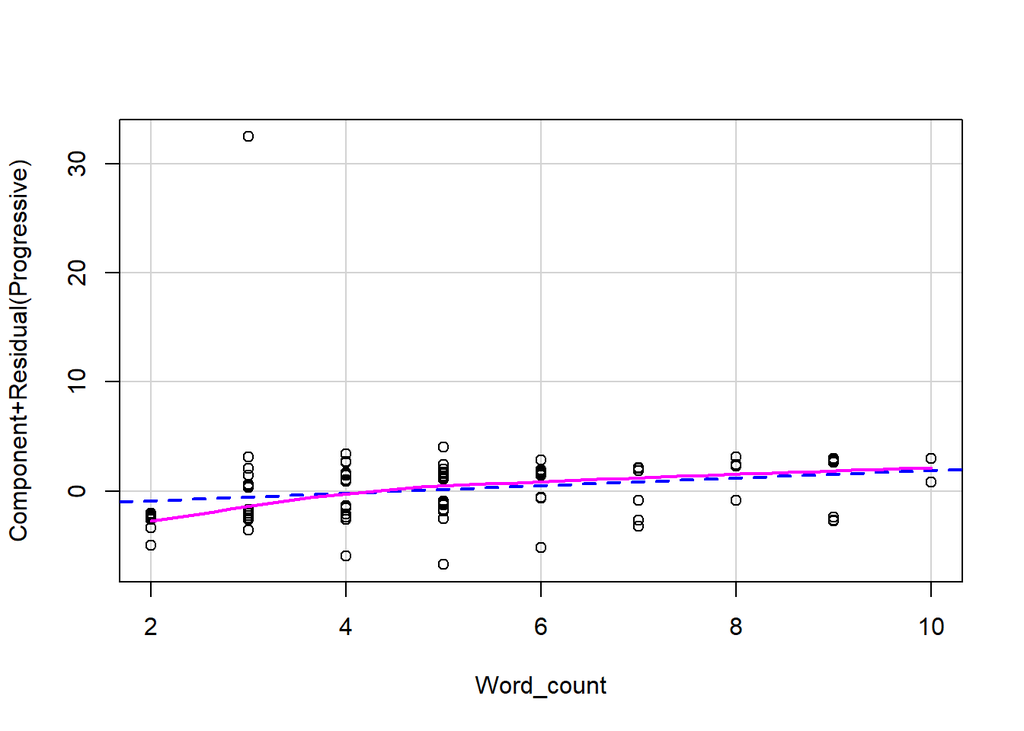

```r
crPlot(model.2, var = "Word_count")
```

(This is not really a great numeric predictor, just take this as an illustration… ^^)

## 6.2. No multicollinearity between explantory variables

To test this assumption, apply the function vif() to the lrm() model. No value should exceed 5 (or others say 10).

```r
vif(model.1)
```

```
##                           GVIF Df GVIF^(1/(2*Df))
## Experiencer           2.095788  2        1.203197
## Subject_group        47.076530  4        1.618455
## Intensifier_presence  1.431002  1        1.196245
## Word_count            9.604647  1        3.099137
## Verb_tense            2.154732  2        1.211570
## Duration              1.907158  1        1.380999
## Pain_at_UT            3.025621  1        1.739431
```

Is there a problem with multicollinearity here? Which predictor should be excluded?

## 6.3. Interdependece of errors

Does not need to be tested, as the observations are independent from one another

# 7. Check for outliers and overly influential cases

Apply the function influencePlot() to the glm() model. Values above 2 and below -2 on the y-axis are problematic

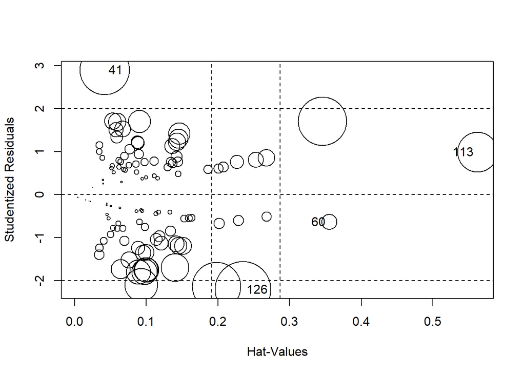

|  | StudRes | Hat | CookD |
| --- | --- | --- | --- |
| 41 | 2.9006581 | 0.04197551 | 0.11320907 |
| 60 | -0.6337847 | 0.35542219 | 0.01101031 |
| 113 | 0.9932727 | 0.56202579 | 0.07379060 |
| 126 | -2.2090520 | 0.23485549 | 0.14299216 |

```r
influencePlot(model.2)
```

Check the data points that appear to be outliers! Is there a valid reason that they should be excluded from the calculation?

```r
ING_data[c(41, 60, 113, 126),]
```

| ID | Text | Verb | Progressive | Experiencer | Subject_group | Intensifier_presence | Verb_tense | Duration | Pain_at_UT | Word_count |
| --- | --- | --- | --- | --- | --- | --- | --- | --- | --- | --- |
| 42 | nine or whatever they call it [S0008:] yeah [S0012:] and er that was hurting and he said well that 'll have to come out | HURT | progressive | 1st | action | NO | past | temporary | NO | 3 |
| 61 | no you ca n't do that it 's going to hurt that 's cruel blah blah blah [S0405:] mm [S0555:] oh shit [S0405:] I | HURT | non-progressive | 3rd | action | NO | future | temporary | NO | 5 |
| 114 | be you 'll regret doing this because [S0421:] your bones will be aching [S0421:] and I 'm just like right cos she 's like | ACHE | progressive | 1st | body part | NO | future | long-term | NO | 5 |
| 127 | up that whole time ? [S0558:] yeah yeah [S0517:] do you not ache ? does your back not not ache ? [S0558:] erm not | ACHE | non-progressive | 2nd | human being | NO | present | long-term | YES | 4 |

-> the hits are all valid utterances and not coding errors. There is no reason why they shouldn’t be included in our model.

Following these checks, you could also check for overfitting and for potential interaction between the predictors, but we will cover these topics in more depth later.